# Risk Factor Analysis

## Outcome Variable

**Outcome Variable:** wast_rec90d

## Predictor Variables

**Intervention Variable:** nrooms

**Adjustment Set:**

- arm
- sex
- W_mage
- meducyrs
- feducyrs
- hhwealth_quart
- hfoodsec
- W_mhtcm
- W_mwtkg
- W_mbmi
- W_nchldlt5
- W_parity
- impfloor
- impsan
- safeh20
- delta_W_mage
- delta_meducyrs
- delta_feducyrs
- delta_hhwealth_quart
- delta_hfoodsec
- delta_W_mhtcm
- delta_W_mwtkg
- delta_W_mbmi
- delta_W_nchldlt5
- delta_W_parity
- delta_impfloor
- delta_impsan
- delta_safeh20

## Stratifying Variables

The analysis was stratified on these variable(s):

- agecat
- studyid
- country

## Data Summary

| agecat | studyid | country | nrooms | wast_rec90d | n_cell | n |
| --- | --- | --- | --- | --- | --- | --- |
| 0-24 months | ki0047075b-MAL-ED | BANGLADESH | 4+ | 0 | 3 | 121 |
| 0-24 months | ki0047075b-MAL-ED | BANGLADESH | 4+ | 1 | 1 | 121 |
| 0-24 months | ki0047075b-MAL-ED | BANGLADESH | 1 | 0 | 31 | 121 |
| 0-24 months | ki0047075b-MAL-ED | BANGLADESH | 1 | 1 | 62 | 121 |
| 0-24 months | ki0047075b-MAL-ED | BANGLADESH | 2 | 0 | 7 | 121 |
| 0-24 months | ki0047075b-MAL-ED | BANGLADESH | 2 | 1 | 9 | 121 |
| 0-24 months | ki0047075b-MAL-ED | BANGLADESH | 3 | 0 | 2 | 121 |
| 0-24 months | ki0047075b-MAL-ED | BANGLADESH | 3 | 1 | 6 | 121 |
| 0-24 months | ki0047075b-MAL-ED | BRAZIL | 4+ | 0 | 5 | 24 |
| 0-24 months | ki0047075b-MAL-ED | BRAZIL | 4+ | 1 | 13 | 24 |
| 0-24 months | ki0047075b-MAL-ED | BRAZIL | 1 | 0 | 0 | 24 |
| 0-24 months | ki0047075b-MAL-ED | BRAZIL | 1 | 1 | 0 | 24 |
| 0-24 months | ki0047075b-MAL-ED | BRAZIL | 2 | 0 | 0 | 24 |
| 0-24 months | ki0047075b-MAL-ED | BRAZIL | 2 | 1 | 2 | 24 |
| 0-24 months | ki0047075b-MAL-ED | BRAZIL | 3 | 0 | 1 | 24 |
| 0-24 months | ki0047075b-MAL-ED | BRAZIL | 3 | 1 | 3 | 24 |
| 0-24 months | ki0047075b-MAL-ED | INDIA | 4+ | 0 | 3 | 175 |
| 0-24 months | ki0047075b-MAL-ED | INDIA | 4+ | 1 | 9 | 175 |
| 0-24 months | ki0047075b-MAL-ED | INDIA | 1 | 0 | 26 | 175 |
| 0-24 months | ki0047075b-MAL-ED | INDIA | 1 | 1 | 38 | 175 |
| 0-24 months | ki0047075b-MAL-ED | INDIA | 2 | 0 | 23 | 175 |
| 0-24 months | ki0047075b-MAL-ED | INDIA | 2 | 1 | 42 | 175 |
| 0-24 months | ki0047075b-MAL-ED | INDIA | 3 | 0 | 14 | 175 |
| 0-24 months | ki0047075b-MAL-ED | INDIA | 3 | 1 | 20 | 175 |
| 0-24 months | ki0047075b-MAL-ED | NEPAL | 4+ | 0 | 14 | 97 |
| 0-24 months | ki0047075b-MAL-ED | NEPAL | 4+ | 1 | 41 | 97 |
| 0-24 months | ki0047075b-MAL-ED | NEPAL | 1 | 0 | 4 | 97 |
| 0-24 months | ki0047075b-MAL-ED | NEPAL | 1 | 1 | 24 | 97 |
| 0-24 months | ki0047075b-MAL-ED | NEPAL | 2 | 0 | 1 | 97 |
| 0-24 months | ki0047075b-MAL-ED | NEPAL | 2 | 1 | 7 | 97 |

[output cut: 354 more lines]

The following strata were considered:

- agecat: 0-24 months, studyid: ki0047075b-MAL-ED, country: BANGLADESH
- agecat: 0-24 months, studyid: ki0047075b-MAL-ED, country: BRAZIL
- agecat: 0-24 months, studyid: ki0047075b-MAL-ED, country: INDIA
- agecat: 0-24 months, studyid: ki0047075b-MAL-ED, country: NEPAL
- agecat: 0-24 months, studyid: ki0047075b-MAL-ED, country: PERU
- agecat: 0-24 months, studyid: ki0047075b-MAL-ED, country: SOUTH AFRICA
- agecat: 0-24 months, studyid: ki0047075b-MAL-ED, country: TANZANIA, UNITED REPUBLIC OF
- agecat: 0-24 months, studyid: ki1000108-CMC-V-BCS-2002, country: INDIA
- agecat: 0-24 months, studyid: ki1000108-IRC, country: INDIA
- agecat: 0-24 months, studyid: ki1017093b-PROVIDE, country: BANGLADESH
- agecat: 0-24 months, studyid: ki1017093c-NIH-Crypto, country: BANGLADESH
- agecat: 0-24 months, studyid: ki1113344-GMS-Nepal, country: NEPAL
- agecat: 0-24 months, studyid: ki1114097-CONTENT, country: PERU
- agecat: 0-24 months, studyid: ki1135781-COHORTS, country: INDIA
- agecat: 0-24 months, studyid: kiGH5241-JiVitA-3, country: BANGLADESH
- agecat: 0-24 months, studyid: kiGH5241-JiVitA-4, country: BANGLADESH
- agecat: 0-6 months, studyid: ki0047075b-MAL-ED, country: BANGLADESH
- agecat: 0-6 months, studyid: ki0047075b-MAL-ED, country: BRAZIL
- agecat: 0-6 months, studyid: ki0047075b-MAL-ED, country: INDIA
- agecat: 0-6 months, studyid: ki0047075b-MAL-ED, country: NEPAL
- agecat: 0-6 months, studyid: ki0047075b-MAL-ED, country: PERU
- agecat: 0-6 months, studyid: ki0047075b-MAL-ED, country: SOUTH AFRICA
- agecat: 0-6 months, studyid: ki0047075b-MAL-ED, country: TANZANIA, UNITED REPUBLIC OF
- agecat: 0-6 months, studyid: ki1000108-CMC-V-BCS-2002, country: INDIA
- agecat: 0-6 months, studyid: ki1000108-IRC, country: INDIA
- agecat: 0-6 months, studyid: ki1017093b-PROVIDE, country: BANGLADESH
- agecat: 0-6 months, studyid: ki1017093c-NIH-Crypto, country: BANGLADESH
- agecat: 0-6 months, studyid: ki1113344-GMS-Nepal, country: NEPAL
- agecat: 0-6 months, studyid: ki1114097-CONTENT, country: PERU
- agecat: 0-6 months, studyid: ki1135781-COHORTS, country: INDIA
- agecat: 0-6 months, studyid: kiGH5241-JiVitA-3, country: BANGLADESH
- agecat: 0-6 months, studyid: kiGH5241-JiVitA-4, country: BANGLADESH
- agecat: 6-24 months, studyid: ki0047075b-MAL-ED, country: BANGLADESH
- agecat: 6-24 months, studyid: ki0047075b-MAL-ED, country: BRAZIL
- agecat: 6-24 months, studyid: ki0047075b-MAL-ED, country: INDIA
- agecat: 6-24 months, studyid: ki0047075b-MAL-ED, country: NEPAL
- agecat: 6-24 months, studyid: ki0047075b-MAL-ED, country: PERU
- agecat: 6-24 months, studyid: ki0047075b-MAL-ED, country: SOUTH AFRICA
- agecat: 6-24 months, studyid: ki0047075b-MAL-ED, country: TANZANIA, UNITED REPUBLIC OF
- agecat: 6-24 months, studyid: ki1000108-CMC-V-BCS-2002, country: INDIA
- agecat: 6-24 months, studyid: ki1000108-IRC, country: INDIA
- agecat: 6-24 months, studyid: ki1017093b-PROVIDE, country: BANGLADESH
- agecat: 6-24 months, studyid: ki1017093c-NIH-Crypto, country: BANGLADESH
- agecat: 6-24 months, studyid: ki1113344-GMS-Nepal, country: NEPAL
- agecat: 6-24 months, studyid: ki1114097-CONTENT, country: PERU
- agecat: 6-24 months, studyid: ki1135781-COHORTS, country: INDIA
- agecat: 6-24 months, studyid: kiGH5241-JiVitA-3, country: BANGLADESH
- agecat: 6-24 months, studyid: kiGH5241-JiVitA-4, country: BANGLADESH

### Dropped Strata

Some strata were dropped due to rare outcomes:

- agecat: 0-24 months, studyid: ki0047075b-MAL-ED, country: BANGLADESH
- agecat: 0-24 months, studyid: ki0047075b-MAL-ED, country: BRAZIL
- agecat: 0-24 months, studyid: ki0047075b-MAL-ED, country: INDIA
- agecat: 0-24 months, studyid: ki0047075b-MAL-ED, country: NEPAL
- agecat: 0-24 months, studyid: ki0047075b-MAL-ED, country: PERU
- agecat: 0-24 months, studyid: ki0047075b-MAL-ED, country: SOUTH AFRICA
- agecat: 0-24 months, studyid: ki0047075b-MAL-ED, country: TANZANIA, UNITED REPUBLIC OF
- agecat: 0-24 months, studyid: ki1000108-CMC-V-BCS-2002, country: INDIA
- agecat: 0-24 months, studyid: ki1017093b-PROVIDE, country: BANGLADESH
- agecat: 0-24 months, studyid: ki1114097-CONTENT, country: PERU
- agecat: 0-24 months, studyid: ki1135781-COHORTS, country: INDIA
- agecat: 0-6 months, studyid: ki0047075b-MAL-ED, country: BANGLADESH
- agecat: 0-6 months, studyid: ki0047075b-MAL-ED, country: BRAZIL
- agecat: 0-6 months, studyid: ki0047075b-MAL-ED, country: INDIA
- agecat: 0-6 months, studyid: ki0047075b-MAL-ED, country: NEPAL
- agecat: 0-6 months, studyid: ki0047075b-MAL-ED, country: PERU
- agecat: 0-6 months, studyid: ki0047075b-MAL-ED, country: SOUTH AFRICA
- agecat: 0-6 months, studyid: ki0047075b-MAL-ED, country: TANZANIA, UNITED REPUBLIC OF
- agecat: 0-6 months, studyid: ki1000108-CMC-V-BCS-2002, country: INDIA
- agecat: 0-6 months, studyid: ki1000108-IRC, country: INDIA
- agecat: 0-6 months, studyid: ki1017093b-PROVIDE, country: BANGLADESH
- agecat: 0-6 months, studyid: ki1017093c-NIH-Crypto, country: BANGLADESH
- agecat: 0-6 months, studyid: ki1114097-CONTENT, country: PERU
- agecat: 0-6 months, studyid: ki1135781-COHORTS, country: INDIA
- agecat: 6-24 months, studyid: ki0047075b-MAL-ED, country: BANGLADESH
- agecat: 6-24 months, studyid: ki0047075b-MAL-ED, country: BRAZIL
- agecat: 6-24 months, studyid: ki0047075b-MAL-ED, country: INDIA
- agecat: 6-24 months, studyid: ki0047075b-MAL-ED, country: NEPAL
- agecat: 6-24 months, studyid: ki0047075b-MAL-ED, country: PERU
- agecat: 6-24 months, studyid: ki0047075b-MAL-ED, country: SOUTH AFRICA
- agecat: 6-24 months, studyid: ki0047075b-MAL-ED, country: TANZANIA, UNITED REPUBLIC OF
- agecat: 6-24 months, studyid: ki1000108-CMC-V-BCS-2002, country: INDIA
- agecat: 6-24 months, studyid: ki1000108-IRC, country: INDIA
- agecat: 6-24 months, studyid: ki1017093b-PROVIDE, country: BANGLADESH
- agecat: 6-24 months, studyid: ki1017093c-NIH-Crypto, country: BANGLADESH
- agecat: 6-24 months, studyid: ki1114097-CONTENT, country: PERU
- agecat: 6-24 months, studyid: ki1135781-COHORTS, country: INDIA
- agecat: 6-24 months, studyid: kiGH5241-JiVitA-3, country: BANGLADESH

## Methods Detail

We’re interested in the causal parameters $E[Y_a]$ for all values of $a \in \mathcal{A}$. These parameters represent the mean outcome if, possibly contrary to fact, we intervened to set all units to have $A=a$. Under the randomization and positivity assumptions, these are identified by the statistical parameters $\psi_a=E_W[E_{Y|A,W}(Y|A=a,W)]$. In addition, we’re interested in the mean of $Y$, $E[Y]$ under no intervention (the observed mean). We will estimate these parameters by using SuperLearner to fit the relevant likelihood factors – $E_{Y|A,W}(Y|A=a,W)$ and $p(A=a|W)$, and then updating our likelihood fit using a joint TMLE.

For unadjusted analyses ($W=\{\}$), initial likelihoods were estimated using Lrnr_glm to estimate the simple $E(Y|A)$ and Lrnr_mean to estimate $p(A)$. For adjusted analyses, a small library containing Lrnr_glmnet, Lrnr_xgboost, and Lrnr_mean was used.

Having estimated these parameters, we will then use the delta method to estimate relative risks and attributable risks relative to a prespecified baseline level of $A$.

# Results Detail

## Results Plots

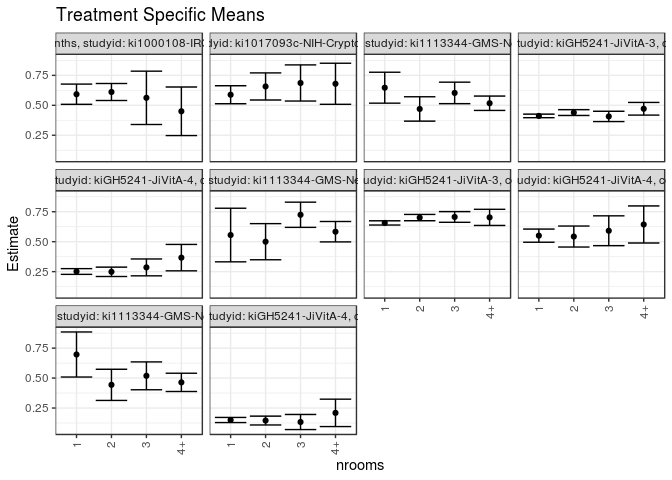

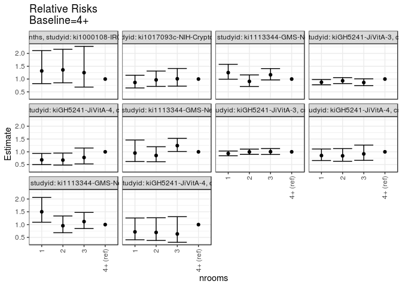

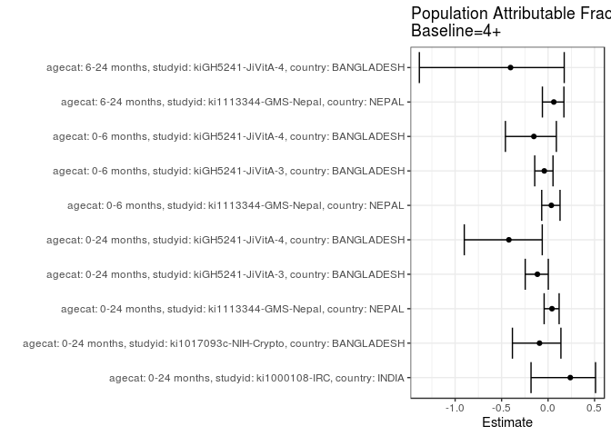

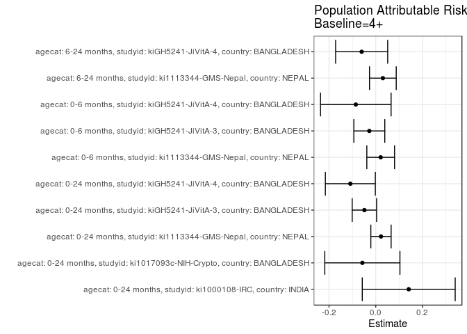

## Results Table

### Parameter: TSM

| agecat | studyid | country | intervention_level | baseline_level | estimate | ci_lower | ci_upper |
| --- | --- | --- | --- | --- | --- | --- | --- |
| 0-24 months | ki1000108-IRC | INDIA | 4+ | NA | 0.4500000 | 0.2471890 | 0.6528110 |
| 0-24 months | ki1000108-IRC | INDIA | 1 | NA | 0.5925926 | 0.5081592 | 0.6770260 |
| 0-24 months | ki1000108-IRC | INDIA | 2 | NA | 0.6111111 | 0.5401543 | 0.6820679 |
| 0-24 months | ki1000108-IRC | INDIA | 3 | NA | 0.5625000 | 0.3398407 | 0.7851593 |
| 0-24 months | ki1017093c-NIH-Crypto | BANGLADESH | 4+ | NA | 0.6798448 | 0.5084217 | 0.8512679 |
| 0-24 months | ki1017093c-NIH-Crypto | BANGLADESH | 1 | NA | 0.5882640 | 0.5131030 | 0.6634250 |
| 0-24 months | ki1017093c-NIH-Crypto | BANGLADESH | 2 | NA | 0.6573160 | 0.5441854 | 0.7704466 |
| 0-24 months | ki1017093c-NIH-Crypto | BANGLADESH | 3 | NA | 0.6864583 | 0.5355308 | 0.8373858 |
| 0-24 months | ki1113344-GMS-Nepal | NEPAL | 4+ | NA | 0.5172060 | 0.4572544 | 0.5771575 |
| 0-24 months | ki1113344-GMS-Nepal | NEPAL | 1 | NA | 0.6469349 | 0.5178390 | 0.7760308 |
| 0-24 months | ki1113344-GMS-Nepal | NEPAL | 2 | NA | 0.4695379 | 0.3678563 | 0.5712194 |
| 0-24 months | ki1113344-GMS-Nepal | NEPAL | 3 | NA | 0.6033381 | 0.5135868 | 0.6930894 |
| 0-24 months | kiGH5241-JiVitA-3 | BANGLADESH | 4+ | NA | 0.4710146 | 0.4180642 | 0.5239651 |
| 0-24 months | kiGH5241-JiVitA-3 | BANGLADESH | 1 | NA | 0.4113127 | 0.3963626 | 0.4262628 |
| 0-24 months | kiGH5241-JiVitA-3 | BANGLADESH | 2 | NA | 0.4393017 | 0.4151329 | 0.4634705 |
| 0-24 months | kiGH5241-JiVitA-3 | BANGLADESH | 3 | NA | 0.4071212 | 0.3641412 | 0.4501011 |
| 0-24 months | kiGH5241-JiVitA-4 | BANGLADESH | 4+ | NA | 0.3667671 | 0.2565735 | 0.4769608 |
| 0-24 months | kiGH5241-JiVitA-4 | BANGLADESH | 1 | NA | 0.2511219 | 0.2273468 | 0.2748971 |
| 0-24 months | kiGH5241-JiVitA-4 | BANGLADESH | 2 | NA | 0.2484081 | 0.2092223 | 0.2875938 |
| 0-24 months | kiGH5241-JiVitA-4 | BANGLADESH | 3 | NA | 0.2853728 | 0.2148405 | 0.3559051 |
| 0-6 months | ki1113344-GMS-Nepal | NEPAL | 4+ | NA | 0.5833333 | 0.4981147 | 0.6685520 |
| 0-6 months | ki1113344-GMS-Nepal | NEPAL | 1 | NA | 0.5555556 | 0.3318457 | 0.7792654 |
| 0-6 months | ki1113344-GMS-Nepal | NEPAL | 2 | NA | 0.5000000 | 0.3491063 | 0.6508937 |
| 0-6 months | ki1113344-GMS-Nepal | NEPAL | 3 | NA | 0.7246377 | 0.6194642 | 0.8298111 |
| 0-6 months | kiGH5241-JiVitA-3 | BANGLADESH | 4+ | NA | 0.7028748 | 0.6354936 | 0.7702560 |
| 0-6 months | kiGH5241-JiVitA-3 | BANGLADESH | 1 | NA | 0.6567034 | 0.6390921 | 0.6743147 |
| 0-6 months | kiGH5241-JiVitA-3 | BANGLADESH | 2 | NA | 0.7011992 | 0.6748664 | 0.7275321 |
| 0-6 months | kiGH5241-JiVitA-3 | BANGLADESH | 3 | NA | 0.7064522 | 0.6617912 | 0.7511133 |
| 0-6 months | kiGH5241-JiVitA-4 | BANGLADESH | 4+ | NA | 0.6437492 | 0.4890277 | 0.7984708 |
| 0-6 months | kiGH5241-JiVitA-4 | BANGLADESH | 1 | NA | 0.5504917 | 0.4955851 | 0.6053983 |
| 0-6 months | kiGH5241-JiVitA-4 | BANGLADESH | 2 | NA | 0.5430885 | 0.4553226 | 0.6308545 |
| 0-6 months | kiGH5241-JiVitA-4 | BANGLADESH | 3 | NA | 0.5912561 | 0.4667789 | 0.7157332 |
| 6-24 months | ki1113344-GMS-Nepal | NEPAL | 4+ | NA | 0.4641923 | 0.3878089 | 0.5405757 |
| 6-24 months | ki1113344-GMS-Nepal | NEPAL | 1 | NA | 0.6968539 | 0.5086942 | 0.8850136 |
| 6-24 months | ki1113344-GMS-Nepal | NEPAL | 2 | NA | 0.4435206 | 0.3135184 | 0.5735229 |
| 6-24 months | ki1113344-GMS-Nepal | NEPAL | 3 | NA | 0.5188215 | 0.4024773 | 0.6351658 |
| 6-24 months | kiGH5241-JiVitA-4 | BANGLADESH | 4+ | NA | 0.2095555 | 0.0950420 | 0.3240690 |
| 6-24 months | kiGH5241-JiVitA-4 | BANGLADESH | 1 | NA | 0.1498994 | 0.1285006 | 0.1712982 |
| 6-24 months | kiGH5241-JiVitA-4 | BANGLADESH | 2 | NA | 0.1454688 | 0.1087064 | 0.1822312 |
| 6-24 months | kiGH5241-JiVitA-4 | BANGLADESH | 3 | NA | 0.1331093 | 0.0699874 | 0.1962312 |

### Parameter: E(Y)

| agecat | studyid | country | intervention_level | baseline_level | estimate | ci_lower | ci_upper |
| --- | --- | --- | --- | --- | --- | --- | --- |
| 0-24 months | ki1000108-IRC | INDIA | NA | NA | 0.5913706 | 0.5391835 | 0.6435576 |
| 0-24 months | ki1017093c-NIH-Crypto | BANGLADESH | NA | NA | 0.6225806 | 0.5684562 | 0.6767051 |
| 0-24 months | ki1113344-GMS-Nepal | NEPAL | NA | NA | 0.5396579 | 0.4973524 | 0.5819633 |
| 0-24 months | kiGH5241-JiVitA-3 | BANGLADESH | NA | NA | 0.4224868 | 0.4113573 | 0.4336163 |
| 0-24 months | kiGH5241-JiVitA-4 | BANGLADESH | NA | NA | 0.2580019 | 0.2386523 | 0.2773515 |
| 0-6 months | ki1113344-GMS-Nepal | NEPAL | NA | NA | 0.6045627 | 0.5449300 | 0.6641955 |
| 0-6 months | kiGH5241-JiVitA-3 | BANGLADESH | NA | NA | 0.6754071 | 0.6620619 | 0.6887522 |
| 0-6 months | kiGH5241-JiVitA-4 | BANGLADESH | NA | NA | 0.5583942 | 0.5167799 | 0.6000084 |
| 6-24 months | ki1113344-GMS-Nepal | NEPAL | NA | NA | 0.4947368 | 0.4401559 | 0.5493178 |
| 6-24 months | kiGH5241-JiVitA-4 | BANGLADESH | NA | NA | 0.1492734 | 0.1316631 | 0.1668838 |

### Parameter: RR

| agecat | studyid | country | intervention_level | baseline_level | estimate | ci_lower | ci_upper |
| --- | --- | --- | --- | --- | --- | --- | --- |
| 0-24 months | ki1000108-IRC | INDIA | 4+ | 4+ | 1.0000000 | 1.0000000 | 1.0000000 |
| 0-24 months | ki1000108-IRC | INDIA | 1 | 4+ | 1.3168724 | 0.8208567 | 2.1126135 |
| 0-24 months | ki1000108-IRC | INDIA | 2 | 4+ | 1.3580247 | 0.8527213 | 2.1627595 |
| 0-24 months | ki1000108-IRC | INDIA | 3 | 4+ | 1.2500000 | 0.6860395 | 2.2775656 |
| 0-24 months | ki1017093c-NIH-Crypto | BANGLADESH | 4+ | 4+ | 1.0000000 | 1.0000000 | 1.0000000 |
| 0-24 months | ki1017093c-NIH-Crypto | BANGLADESH | 1 | 4+ | 0.8652916 | 0.6522721 | 1.1478792 |
| 0-24 months | ki1017093c-NIH-Crypto | BANGLADESH | 2 | 4+ | 0.9668619 | 0.7125358 | 1.3119648 |
| 0-24 months | ki1017093c-NIH-Crypto | BANGLADESH | 3 | 4+ | 1.0097280 | 0.7222492 | 1.4116327 |
| 0-24 months | ki1113344-GMS-Nepal | NEPAL | 4+ | 4+ | 1.0000000 | 1.0000000 | 1.0000000 |
| 0-24 months | ki1113344-GMS-Nepal | NEPAL | 1 | 4+ | 1.2508265 | 0.9928566 | 1.5758236 |
| 0-24 months | ki1113344-GMS-Nepal | NEPAL | 2 | 4+ | 0.9078354 | 0.7100649 | 1.1606898 |
| 0-24 months | ki1113344-GMS-Nepal | NEPAL | 3 | 4+ | 1.1665336 | 0.9659715 | 1.4087377 |
| 0-24 months | kiGH5241-JiVitA-3 | BANGLADESH | 4+ | 4+ | 1.0000000 | 1.0000000 | 1.0000000 |
| 0-24 months | kiGH5241-JiVitA-3 | BANGLADESH | 1 | 4+ | 0.8732482 | 0.7760288 | 0.9826470 |
| 0-24 months | kiGH5241-JiVitA-3 | BANGLADESH | 2 | 4+ | 0.9326710 | 0.8230550 | 1.0568858 |
| 0-24 months | kiGH5241-JiVitA-3 | BANGLADESH | 3 | 4+ | 0.8643493 | 0.7408956 | 1.0083738 |
| 0-24 months | kiGH5241-JiVitA-4 | BANGLADESH | 4+ | 4+ | 1.0000000 | 1.0000000 | 1.0000000 |
| 0-24 months | kiGH5241-JiVitA-4 | BANGLADESH | 1 | 4+ | 0.6846904 | 0.4996833 | 0.9381961 |
| 0-24 months | kiGH5241-JiVitA-4 | BANGLADESH | 2 | 4+ | 0.6772910 | 0.4823837 | 0.9509508 |
| 0-24 months | kiGH5241-JiVitA-4 | BANGLADESH | 3 | 4+ | 0.7780762 | 0.5273248 | 1.1480640 |
| 0-6 months | ki1113344-GMS-Nepal | NEPAL | 4+ | 4+ | 1.0000000 | 1.0000000 | 1.0000000 |
| 0-6 months | ki1113344-GMS-Nepal | NEPAL | 1 | 4+ | 0.9523810 | 0.6205522 | 1.4616490 |
| 0-6 months | ki1113344-GMS-Nepal | NEPAL | 2 | 4+ | 0.8571429 | 0.6129707 | 1.1985790 |
| 0-6 months | ki1113344-GMS-Nepal | NEPAL | 3 | 4+ | 1.2422360 | 1.0110429 | 1.5262956 |
| 0-6 months | kiGH5241-JiVitA-3 | BANGLADESH | 4+ | 4+ | 1.0000000 | 1.0000000 | 1.0000000 |
| 0-6 months | kiGH5241-JiVitA-3 | BANGLADESH | 1 | 4+ | 0.9343107 | 0.8457849 | 1.0321021 |
| 0-6 months | kiGH5241-JiVitA-3 | BANGLADESH | 2 | 4+ | 0.9976162 | 0.9000161 | 1.1058002 |
| 0-6 months | kiGH5241-JiVitA-3 | BANGLADESH | 3 | 4+ | 1.0050898 | 0.8960506 | 1.1273977 |
| 0-6 months | kiGH5241-JiVitA-4 | BANGLADESH | 4+ | 4+ | 1.0000000 | 1.0000000 | 1.0000000 |
| 0-6 months | kiGH5241-JiVitA-4 | BANGLADESH | 1 | 4+ | 0.8551338 | 0.6591866 | 1.1093276 |
| 0-6 months | kiGH5241-JiVitA-4 | BANGLADESH | 2 | 4+ | 0.8436337 | 0.6315007 | 1.1270262 |
| 0-6 months | kiGH5241-JiVitA-4 | BANGLADESH | 3 | 4+ | 0.9184571 | 0.6672819 | 1.2641787 |
| 6-24 months | ki1113344-GMS-Nepal | NEPAL | 4+ | 4+ | 1.0000000 | 1.0000000 | 1.0000000 |
| 6-24 months | ki1113344-GMS-Nepal | NEPAL | 1 | 4+ | 1.5012182 | 1.0934582 | 2.0610354 |
| 6-24 months | ki1113344-GMS-Nepal | NEPAL | 2 | 4+ | 0.9554675 | 0.6828040 | 1.3370136 |
| 6-24 months | ki1113344-GMS-Nepal | NEPAL | 3 | 4+ | 1.1176867 | 0.8458962 | 1.4768048 |
| 6-24 months | kiGH5241-JiVitA-4 | BANGLADESH | 4+ | 4+ | 1.0000000 | 1.0000000 | 1.0000000 |
| 6-24 months | kiGH5241-JiVitA-4 | BANGLADESH | 1 | 4+ | 0.7153208 | 0.4066208 | 1.2583810 |
| 6-24 months | kiGH5241-JiVitA-4 | BANGLADESH | 2 | 4+ | 0.6941780 | 0.3801711 | 1.2675424 |
| 6-24 months | kiGH5241-JiVitA-4 | BANGLADESH | 3 | 4+ | 0.6351985 | 0.3080687 | 1.3096986 |

### Parameter: PAR

| agecat | studyid | country | intervention_level | baseline_level | estimate | ci_lower | ci_upper |
| --- | --- | --- | --- | --- | --- | --- | --- |
| 0-24 months | ki1000108-IRC | INDIA | 4+ | NA | 0.1413706 | -0.0576416 | 0.3403827 |
| 0-24 months | ki1017093c-NIH-Crypto | BANGLADESH | 4+ | NA | -0.0572641 | -0.2182547 | 0.1037264 |
| 0-24 months | ki1113344-GMS-Nepal | NEPAL | 4+ | NA | 0.0224519 | -0.0210160 | 0.0659198 |
| 0-24 months | kiGH5241-JiVitA-3 | BANGLADESH | 4+ | NA | -0.0485279 | -0.1008048 | 0.0037490 |
| 0-24 months | kiGH5241-JiVitA-4 | BANGLADESH | 4+ | NA | -0.1087652 | -0.2157763 | -0.0017541 |
| 0-6 months | ki1113344-GMS-Nepal | NEPAL | 4+ | NA | 0.0212294 | -0.0381741 | 0.0806329 |
| 0-6 months | kiGH5241-JiVitA-3 | BANGLADESH | 4+ | NA | -0.0274677 | -0.0937573 | 0.0388219 |
| 0-6 months | kiGH5241-JiVitA-4 | BANGLADESH | 4+ | NA | -0.0853551 | -0.2365054 | 0.0657953 |
| 6-24 months | ki1113344-GMS-Nepal | NEPAL | 4+ | NA | 0.0305446 | -0.0266949 | 0.0877840 |
| 6-24 months | kiGH5241-JiVitA-4 | BANGLADESH | 4+ | NA | -0.0602821 | -0.1717761 | 0.0512120 |

### Parameter: PAF

| agecat | studyid | country | intervention_level | baseline_level | estimate | ci_lower | ci_upper |
| --- | --- | --- | --- | --- | --- | --- | --- |
| 0-24 months | ki1000108-IRC | INDIA | 4+ | NA | 0.2390558 | -0.1833208 | 0.5106685 |
| 0-24 months | ki1017093c-NIH-Crypto | BANGLADESH | 4+ | NA | -0.0919787 | -0.3835921 | 0.1381727 |
| 0-24 months | ki1113344-GMS-Nepal | NEPAL | 4+ | NA | 0.0416039 | -0.0424146 | 0.1188506 |
| 0-24 months | kiGH5241-JiVitA-3 | BANGLADESH | 4+ | NA | -0.1148625 | -0.2459217 | 0.0024106 |
| 0-24 months | kiGH5241-JiVitA-4 | BANGLADESH | 4+ | NA | -0.4215673 | -0.9015574 | -0.0627361 |
| 0-6 months | ki1113344-GMS-Nepal | NEPAL | 4+ | NA | 0.0351153 | -0.0684841 | 0.1286698 |
| 0-6 months | kiGH5241-JiVitA-3 | BANGLADESH | 4+ | NA | -0.0406684 | -0.1436130 | 0.0530094 |
| 0-6 months | kiGH5241-JiVitA-4 | BANGLADESH | 4+ | NA | -0.1528581 | -0.4589984 | 0.0890451 |
| 6-24 months | ki1113344-GMS-Nepal | NEPAL | 4+ | NA | 0.0617390 | -0.0611009 | 0.1703582 |
| 6-24 months | kiGH5241-JiVitA-4 | BANGLADESH | 4+ | NA | -0.4038365 | -1.3848102 | 0.1736210 |